# Workshop Flanders - inundation time series

### 1.1.4 Step 4: Classification

#### 1.1.4.1 Jussila’s (Jussila et al., 2024) inundation classification

```r
predictions <- predict(tree_jussila, obj_df, type = "class")

# Convert factor to numeric codes
pred_numeric <- as.numeric(predictions)

# Set predictions to NA if the corresponding row in obj_df contains any NA (masked out values are set to NA instead of 1 or 2)
pred_numeric[!complete.cases(obj_df)] <- NA

# Store levels for later labeling
(pred_levels <- levels(predictions))
```

```
## [1] "dry"   "water"
```

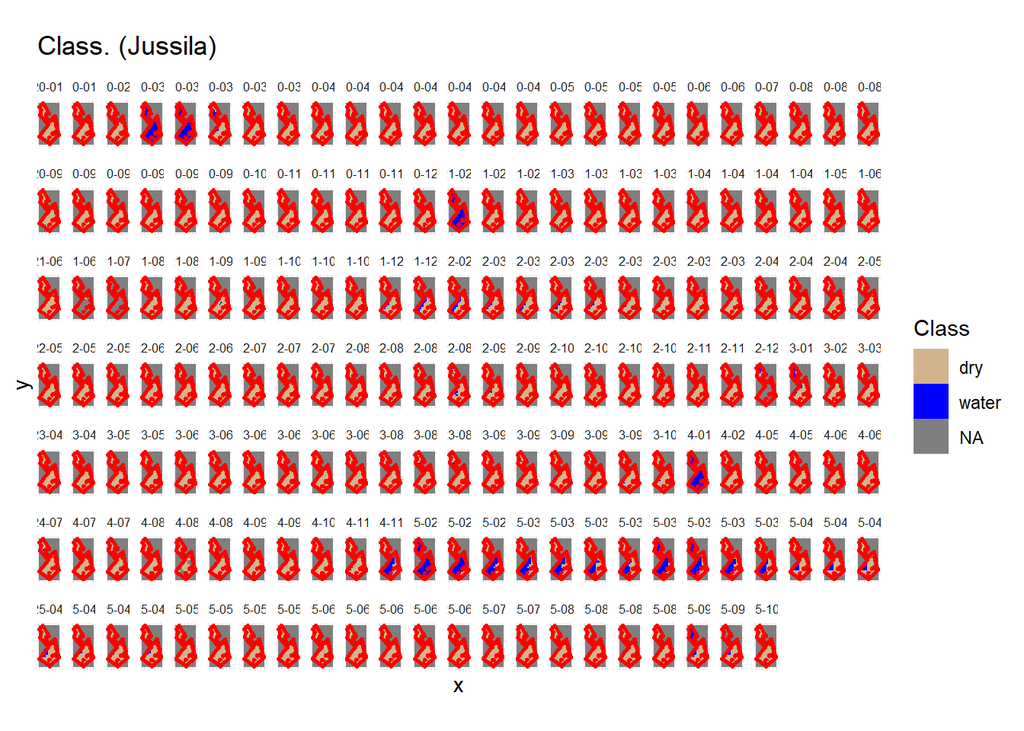

```r
# Reshape to array
pred_array <- array(pred_numeric, dim = c(nx, ny, nt))

# Create stars object
obj_classified <- st_as_stars(pred_array, dimensions = st_dimensions(obj_poly))
st_crs(obj_classified) <- st_crs(obj_poly)

# Visualize
# Convert the stars object to factor using st_set_dimensions
obj_classified_factor <- obj_classified[AOI]
obj_classified_factor[[1]] <- factor(
  obj_classified_factor[[1]],
  levels = c(1, 2),
  labels = pred_levels
)

# Plot with discrete scale
ggplot() +
  ggtitle("Class. (Jussila)") +
  geom_stars(data = obj_classified_factor) +
  geom_sf(data = AOI, fill = NA, color = "red", linewidth = 1) +
  facet_wrap(~t, ncol = 25) +
  theme_minimal() +
  theme(
    strip.text = element_text(size = 6),   # <-- make facet titles smaller,
    axis.text = element_blank(),          # remove axis tick labels
    axis.ticks = element_blank(),         # remove tick marks
  ) +
  scale_fill_manual(
    name = "Class",
    values = c("dry" = "tan", "water" = "blue")
  )
```

#### 1.1.4.2 Wiw (Lefebre et al., 2019) inundation classification

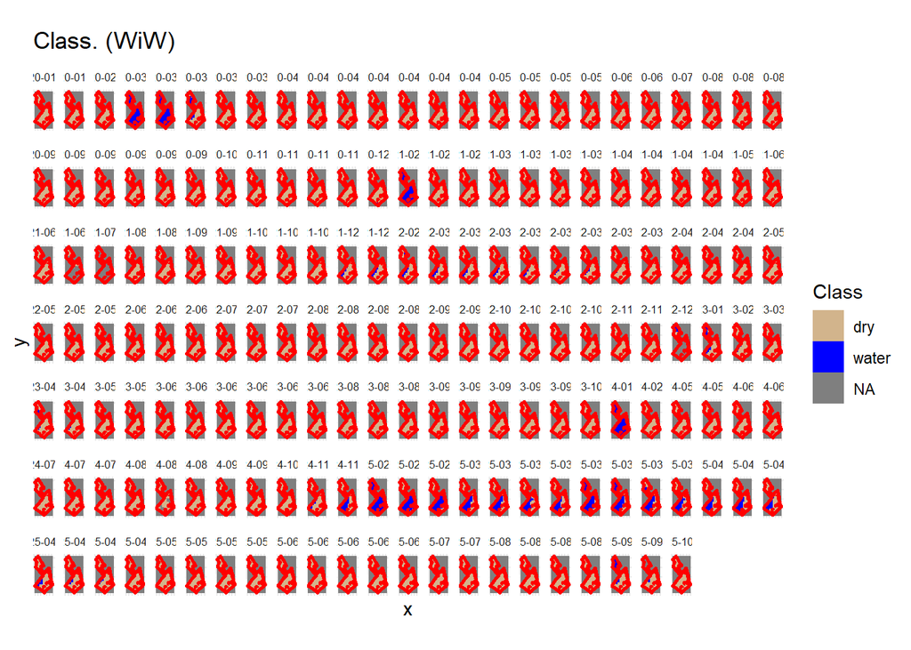

```r
watercl_wiw <- obj_df$b8a <= 1804 & obj_df$b12 <= 1131
watercl_wiw <- watercl_wiw*1
pred_levels <- c("dry" , "water")

# Reshape to array
wiw_array <- array(watercl_wiw, dim = c(nx, ny, nt))

# Create stars object
obj_classified_wiw <- st_as_stars(wiw_array, dimensions = st_dimensions(obj_poly))
st_crs(obj_classified_wiw) <- st_crs(obj_poly)

# Visualize
# Convert the stars object to factor using st_set_dimensions
obj_classified_wiw_factor <- obj_classified_wiw[AOI]
obj_classified_wiw_factor[[1]] <- factor(
  obj_classified_wiw_factor[[1]],
  levels = c(0, 1),
  labels = pred_levels
)

# Plot with discrete scale
ggplot() +
  ggtitle("Class. (WiW)") +
  geom_stars(data = obj_classified_wiw_factor) +
  geom_sf(data = AOI, fill = NA, color = "red", linewidth = 1) +
  facet_wrap(~t, ncol = 25) +
  theme_minimal()+
    theme(
    strip.text = element_text(size = 6),   # <-- make facet titles smaller,
    axis.text = element_blank(),          # remove axis tick labels
    axis.ticks = element_blank(),         # remove tick marks
  ) +
  scale_fill_manual(
    name = "Class",
    values = c("dry" = "tan", "water" = "blue")
  )
```

### 1.1.5 Visual comparison between the models

*Question 2: can you already spot some differences between the two models?*

We can check the output of both classifications and compare it with an ortho image with the same date. E.g. 01/03/2023.

```r
# Extract the time values
times <- st_get_dimension_values(obj_classified_wiw, "t")

# Define your desired time
target_time <- as.POSIXct("2023-03-01", tz = "UTC")

# Find index of the nearest timestamp
i <- which.min(abs(times - target_time))

# Extract that layer
layer_2023_03_01_wiw <- obj_classified_wiw[,,,i]
layer_2023_03_01_Tytti <- obj_classified[,,,i] - 1 # convert values [1,2] --> [0,1]


layer_2023_03_01_wiw <- layer_2023_03_01_wiw %>% st_warp(crs=4326)
layer_2023_03_01_Tytti <- layer_2023_03_01_Tytti %>% st_warp(crs=4326)

# Define your color palette
palette_function <- function(stars_data){
  if (min(stars_data, na.rm=T) == max(stars_data, na.rm=T)){
    if (max(stars_data, na.rm=T)==1){
      palette <- colorFactor(palette = "blue",domain = 1,na.color = "transparent")
    } else {
      palette <- colorFactor(palette = "tan",domain = 0,na.color = "transparent")
    }

  }else {
    palette <- colorFactor(palette = c("tan","blue"),domain= c(0,1),na.color = "transparent")
  }
}

# Base map (your existing code)
layer <- "OMWRGB23VL"

map <- leaflet() %>%
  addTiles(group = "OpenStreetMap") %>%  # <-- Adds OSM as base map
  addWMSTiles(
    wms_ortho,
    layers = layer,
    options = WMSTileOptions(format = "image/png", transparent = FALSE),
    group = "OMWRGB20VL"
  ) %>%
  addWMSTiles(
    wms_DEM,
    layers = "DHMV_II_HILL_25cm",
    options = WMSTileOptions(format = "image/png", transparent = TRUE),
    group = "DHMV_II_HILL_25cm"
  ) %>%
  fitBounds(
    lng1 = bb[["xmin"]],
    lat1 = bb[["ymin"]],
    lng2 = bb[["xmax"]],
    lat2 = bb[["ymax"]]
  ) %>%
  addPolygons(data = AOI_wgs84, color = "red", weight = 2) %>%
  addMarkers(
    data = points_wgs84,
    lng = st_coordinates(points_wgs84)[,1],
    lat = st_coordinates(points_wgs84)[,2],
    popup = points_wgs84$label
  ) %>%
  addStarsImage(
    layer_2023_03_01_wiw,
    colors = palette_function(layer_2023_03_01_wiw[["X"]]),
    opacity = 0.8,
    group = "2023-03-01 Wiw"
  ) %>%
  addStarsImage(
    layer_2023_03_01_Tytti,
    colors = palette_function(layer_2023_03_01_Tytti[["X"]]),
    opacity = 0.8,
    group = "2023-03-01 Tytti"
  ) %>%
  addLayersControl(
    baseGroups = c("OpenStreetMap","OMWRGB23VL", "DHMV_II_HILL_25cm"),
    overlayGroups = c("2023-03-01 Wiw", "2023-03-01 Tytti"),
    options = layersControlOptions(collapsed = FALSE)
  )

map
```

[interactive chart not shown]

### 1.1.6 Step 5: Visualize output for the last available date

Compare the classification results based on the last available Sentinel-2 image and compare it with the field data of 15/10/2025 (GPS coordinates).

```r
# Extract the time values
times <- st_get_dimension_values(obj_classified_wiw, "t")

# Define your desired time
target_time <- as.POSIXct("2025-10-15", tz = "UTC")

# Find index of the nearest timestamp
i <- which.min(abs(times - target_time))

# Extract that layer
layer_last_wiw <- obj_classified_wiw[,,,i]
layer_last_Tytti <- obj_classified[,,,i] - 1 # convert values [1,2] --> [0,1]

layer_last_wiw <- layer_last_wiw %>% st_warp(crs=4326)
layer_last_Tytti <- layer_last_Tytti %>% st_warp(crs=4326)

# Extract the time value from the layer
date_value <- st_get_dimension_values(obj_classified_wiw[,,,i], "t")
date_value
```

```
## [1] "2025-10-01 UTC"
```

```r
# Define your color palette
palette_function <- function(stars_data){
  if (min(stars_data, na.rm=T) == max(stars_data, na.rm=T)){
    if (max(stars_data, na.rm=T)==1){ # Check if your layer has 0 and 1 values, only 0 values (completely dry) or only 1 values (completely inundated). If you only define 1 color palette, the results will be interpolated.
      palette <- colorFactor(palette = "blue",domain = 1,na.color = "transparent")
    } else {
      palette <- colorFactor(palette = "tan",domain = 0,na.color = "transparent")
    }

  }else {
    palette <- colorFactor(palette = c("tan","blue"),domain= c(0,1),na.color = "transparent")
  }
}


# Create map with OSM background
map <- leaflet() %>%
  addTiles(group = "OpenStreetMap") %>%  # <-- Adds OSM as base map
  addWMSTiles(
    wms_ortho,
    layers = layer,
    options = WMSTileOptions(format = "image/png", transparent = FALSE),
    group = "OMWRGB20VL"
  ) %>%
  addWMSTiles(
    wms_DEM,
    layers = "DHMV_II_HILL_25cm",
    options = WMSTileOptions(format = "image/png", transparent = TRUE),
    group = "DHMV_II_HILL_25cm"
  ) %>%
  fitBounds(
    lng1 = bb[["xmin"]],
    lat1 = bb[["ymin"]],
    lng2 = bb[["xmax"]],
    lat2 = bb[["ymax"]]
  ) %>%
  addPolygons(data = AOI_wgs84, color = "red", weight = 2) %>%
  addMarkers(
    data = points_wgs84,
    lng = st_coordinates(points_wgs84)[,1],
    lat = st_coordinates(points_wgs84)[,2],
    popup = points_wgs84$label
  ) %>%
  addStarsImage(
    layer_last_wiw,
    colors = palette_function(layer_last_wiw[["X"]]),
    opacity = 0.8,
    group = paste0(date_value, " Wiw. cl")
  ) %>%
  addStarsImage(
    layer_last_Tytti,
    colors = palette_function(layer_last_Tytti[["X"]]),
    opacity = 0.8,
    group = paste0(date_value, " Juss. cl")
  ) %>%
  addLayersControl(
    baseGroups = c("OpenStreetMap","OMWRGB20VL", "DHMV_II_HILL_25cm"),
    overlayGroups = c(paste0(date_value, " Wiw. cl"), paste0(date_value, " Juss. cl")),
    options = layersControlOptions(collapsed = FALSE)
  )

map
```

[interactive chart not shown]

You can also visualize a vegetation/soil moisture index for the last date.

Add soil moisture/wetness indices to your stars object.

```r
obj_wetness <-
  obj_poly |>
  mutate(NDMI = (B8A - B11) / (B8A + B11), # Gao's Moisture index
         NDWI = (B03 - B8A) / (B03 + B8A), # Mcfeeters Water index
         NDPI = (B03-B11)/(B03+B11), # Pond index. from slovakia Clizsky potok example
         STR = ((1-B11/10000)^2)/(2*B11/10000)) # Transformed SWIR. Should be linearly correlated with soil moisture (Sadeghi et al.,2017, https://doi.org/10.1016/j.rse.2017.05.041)
```

Visualize the different soil moisture indices for the last available date.

```r
# Extract that layer
obj_wetness_last <- obj_wetness[,,,i]

obj_wetness_last <- obj_wetness_last %>% st_warp(crs=4326)

# Extract the time value from the layer
date_value <- st_get_dimension_values(obj_wetness_last, "t")
date_value
```

```
## [1] "2025-10-01 UTC"
```

```r
# Define a viridis palette (yellow -> blue)
# direction = -1 flips the default viridis (blue -> yellow) to yellow -> blue
viridis_pal <- viridis::viridis(256, option = "D", direction = -1)

# You can define a function to generate color scales for each layer dynamically
palette_function <- function(layer) {
  # Extract the numeric values safely
  layer_values <- as.vector(st_as_stars(layer)[[1]])

  leaflet::colorNumeric(
    palette = viridis_pal,
    domain = layer_values,
    na.color = "transparent"
  )
}

# Create map with OSM background
map <- leaflet() %>%
  addTiles(group = "OpenStreetMap") %>%
  addWMSTiles(
    wms_ortho,
    layers = layer,
    options = WMSTileOptions(format = "image/png", transparent = FALSE),
    group = "OMWRGB20VL"
  ) %>%
  addWMSTiles(
    wms_DEM,
    layers = "DHMV_II_HILL_25cm",
    options = WMSTileOptions(format = "image/png", transparent = TRUE),
    group = "DHMV_II_HILL_25cm"
  ) %>%
  fitBounds(
    lng1 = bb[["xmin"]],
    lat1 = bb[["ymin"]],
    lng2 = bb[["xmax"]],
    lat2 = bb[["ymax"]]
  ) %>%
  addPolygons(data = AOI_wgs84, color = "red", weight = 2) %>%
  addMarkers(
    data = points_wgs84,
    lng = st_coordinates(points_wgs84)[,1],
    lat = st_coordinates(points_wgs84)[,2],
    popup = points_wgs84$label
  ) %>%
  addStarsImage(
    -obj_wetness_last["B11"],
    colors = palette_function(-obj_wetness_last["B11"]), # multiply with -1 (because high values normally inidicate dry spots, not wet spots like in the other indices).
    opacity = 0.8,
    group = paste0(date_value, " B11")
  ) %>%
  addStarsImage(
    obj_wetness_last["NDWI"],
    colors = palette_function(obj_wetness_last["NDWI"]),
    opacity = 0.8,
    group = paste0(date_value, " NDWI")
  ) %>%
  addStarsImage(
    obj_wetness_last["NDMI"],
    colors = palette_function(obj_wetness_last["NDMI"]),
    opacity = 0.8,
    group = paste0(date_value, " NDMI")
  ) %>%
  addStarsImage(
    obj_wetness_last["NDPI"],
    colors = palette_function(obj_wetness_last["NDPI"]),
    opacity = 0.8,
    group = paste0(date_value, " NDPI")
  ) %>%
  addStarsImage(
    obj_wetness_last["STR"],
    colors = palette_function(obj_wetness_last["STR"]),
    opacity = 0.8,
    group = paste0(date_value, " STR")
  ) %>%
  addLayersControl(
    baseGroups = c("OpenStreetMap","OMWRGB20VL", "DHMV_II_HILL_25cm"),
    overlayGroups = c(
      paste0(date_value, " B11"),
      paste0(date_value, " NDWI"),
      paste0(date_value, " NDMI"),
      paste0(date_value, " NDPI"),
      paste0(date_value, " STR")
    ),
    options = layersControlOptions(collapsed = FALSE)
  )

map
```

[interactive chart not shown]

*Question 3: What can we conclude based form the last available Sentinel-2 image data? Does it match with our observations in the field?*

### 1.1.7 Step 6: Indicator analysis

*Question 4: in which case do we want to monitor on pixel level / on plot level?*

Problem of missing data:

[figure not shown]

```r
plot(obj_classified[,,,130],main="2024-08-19",col=c("tan"))
```

We first analyse without dealing with missing values.

- Proportion of inundation

```r
# Calculate the proportion of "water" pixels for each times tamp and visualize
# Convert the classified stars object to a tibble
classified_pixels <- as_tibble(obj_classified[AOI])

# Rename the column for clarity and filter out NA values
names(classified_pixels)[which(names(classified_pixels) == "X")] <- "Class"
classified_pixels <- classified_pixels %>% dplyr::filter(!is.na(Class))

# Calculate total pixels and water pixels for each time step
water_proportion_data <- classified_pixels %>%
  group_by(t) %>%
  summarize(
    total_pixels = n(),
    water_pixels = sum(Class == 2, na.rm = TRUE), # Class 2 is 'water'
    .groups = "drop"
  ) %>%
  mutate(
    proportion_water = water_pixels / total_pixels
  )

# Print the resulting tibble with proportions
print(water_proportion_data)
```

```
## # A tibble: 172 × 4
##    t                   total_pixels water_pixels proportion_water
##    <dttm>                     <int>        <int>            <dbl>
##  1 2020-01-06 00:00:00          397           10          0.0252
##  2 2020-01-16 00:00:00          397           22          0.0554
##  3 2020-02-07 00:00:00          397            1          0.00252
##  4 2020-03-16 00:00:00          397          397          1
##  5 2020-03-18 00:00:00          397          396          0.997
##  6 2020-03-23 00:00:00          397           65          0.164
##  7 2020-03-26 00:00:00          397            0          0
##  8 2020-03-28 00:00:00          397            0          0
##  9 2020-04-05 00:00:00          397            1          0.00252
## 10 2020-04-07 00:00:00          397            0          0
## # ℹ 162 more rows
```

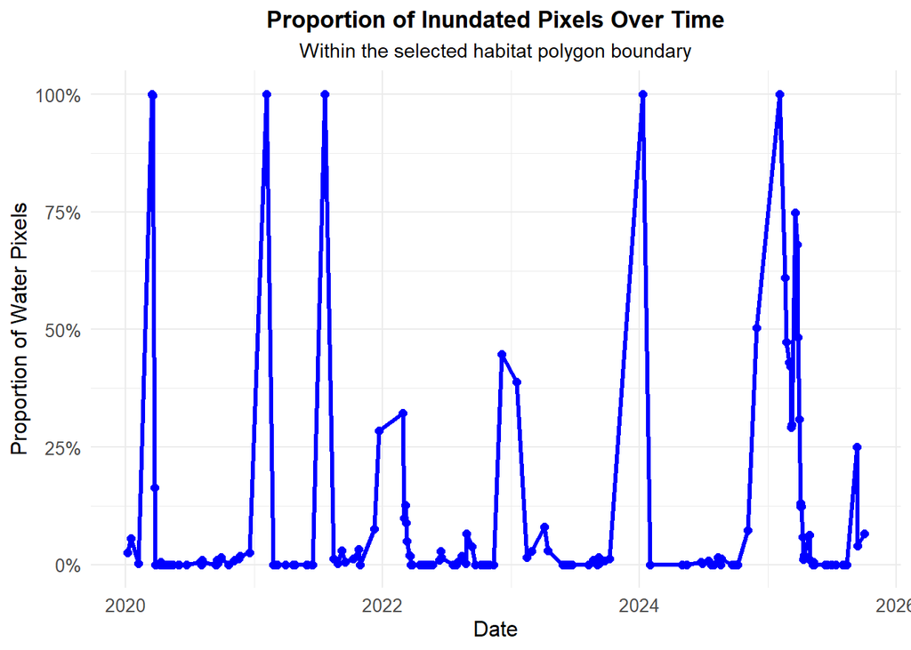

```r
# Visualize the time series of water proportion
ggplot(water_proportion_data, aes(x = t, y = proportion_water)) +
  geom_line(color = "blue", size = 1.2) +
  geom_point(color = "blue", size = 2) +
  labs(
    title = "Proportion of Inundated Pixels Over Time",
    subtitle = "Within the selected habitat polygon boundary",
    x = "Date",
    y = "Proportion of Water Pixels"
  ) +
  theme_minimal() +
  scale_y_continuous(labels = scales::percent_format()) +
  theme(
    plot.title = element_text(hjust = 0.5, face = "bold"),
    plot.subtitle = element_text(hjust = 0.5),
    axis.title = element_text(size = 12),
    axis.text = element_text(size = 10)
  )
```

Be aware you have missing data! Visualize the true time series.

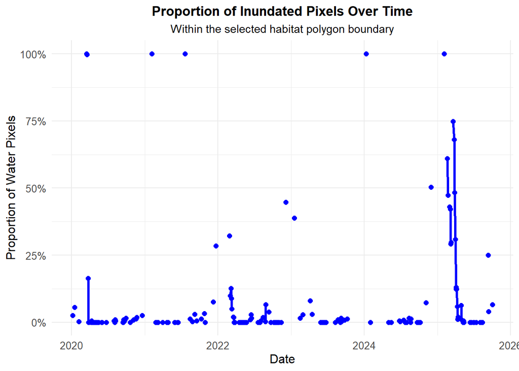

```r
# Fill in every 5-day step (revisit time Sentinel 2 --> for Belgium even up to 2/3 days revisit time).
water_proportion_data2 <- water_proportion_data %>%
  mutate(t = as.Date(t))

water_proportion_data_complete <- water_proportion_data2 %>%
  complete(t = seq.Date(min(t), max(t), by = "5 days"))

ggplot(water_proportion_data_complete, aes(x = t, y = proportion_water)) +
  geom_line(color = "blue", size = 1.2, na.rm = FALSE) +
  geom_point(color = "blue", size = 2) +
  labs(
    title = "Proportion of Inundated Pixels Over Time",
    subtitle = "Within the selected habitat polygon boundary",
    x = "Date",
    y = "Proportion of Water Pixels"
  ) +
  theme_minimal() +
  scale_y_continuous(labels = scales::percent_format()) +
  theme(
    plot.title = element_text(hjust = 0.5, face = "bold"),
    plot.subtitle = element_text(hjust = 0.5),
    axis.title = element_text(size = 12),
    axis.text = element_text(size = 10)
  )
```

Water/soil moisture indices

```r
Juss_cl <- obj_classified-1 # convert values form 1-2 to 0-1
obj_wetness <- c(obj_wetness,Juss_cl)
obj_wetness <- c(obj_wetness,obj_classified_factor)
obj_wetness <- c(obj_wetness,obj_classified_wiw)
obj_wetness <- c(obj_wetness,obj_classified_wiw_factor)
names(obj_wetness)[14] <- "Juss_cl"
names(obj_wetness)[15] <- "Juss_cl_fact"
names(obj_wetness)[16] <- "Wiw_cl"
names(obj_wetness)[17] <- "Wiw_cl_fact"


obj_wetness
```

```
## stars object with 3 dimensions and 17 attributes
## attribute(s):
##       B02              B03              B04              B05
##  Min.   : -33.0   Min.   :  62.0   Min.   :  95.0   Min.   : 342
##  1st Qu.: 308.0   1st Qu.: 594.0   1st Qu.: 340.0   1st Qu.:1006
##  Median : 375.0   Median : 675.0   Median : 486.0   Median :1150
##  Mean   : 410.2   Mean   : 686.5   Mean   : 566.1   Mean   :1166
##  3rd Qu.: 484.0   3rd Qu.: 764.0   3rd Qu.: 718.0   3rd Qu.:1313
##  Max.   :3476.0   Max.   :3520.0   Max.   :3756.0   Max.   :3894
##  NA's   :99391    NA's   :99391    NA's   :99391    NA's   :99391
##       B08             B8A             B11             B12
##  Min.   : 142    Min.   : 100    Min.   :  40    Min.   :  32
##  1st Qu.:2425    1st Qu.:2507    1st Qu.:1914    1st Qu.: 948
##  Median :3407    Median :3533    Median :2201    Median :1135
##  Mean   :3386    Mean   :3464    Mean   :2169    Mean   :1229
##  3rd Qu.:4453    3rd Qu.:4531    3rd Qu.:2504    3rd Qu.:1494
##  Max.   :6445    Max.   :6418    Max.   :4496    Max.   :4416
##  NA's   :99391   NA's   :99391   NA's   :99391   NA's   :99391
##       SCL            NDMI             NDWI             NDPI
##  Min.   :4.000   Min.   :-0.274   Min.   :-0.862   Min.   :-0.789
##  1st Qu.:4.000   1st Qu.: 0.065   1st Qu.:-0.743   1st Qu.:-0.561
##  Median :4.000   Median : 0.232   Median :-0.667   Median :-0.524
##  Mean   :4.226   Mean   : 0.207   Mean   :-0.627   Mean   :-0.495
##  3rd Qu.:4.000   3rd Qu.: 0.362   3rd Qu.:-0.560   3rd Qu.:-0.482
##  Max.   :6.000   Max.   : 0.828   Max.   : 0.756   Max.   : 0.866
##  NA's   :99391   NA's   :99391    NA's   :99391    NA's   :99391
##       STR             Juss_cl      Juss_cl_fact     Wiw_cl       Wiw_cl_fact
##  Min.   :  0.337   Min.   :0.000   dry  :61648   Min.   :0.00    dry  :61047
##  1st Qu.:  1.122   1st Qu.:0.000   water: 5457   1st Qu.:0.00    water: 6058
##  Median :  1.382   Median :0.000   NA's :99391   Median :0.00    NA's :99391
##  Mean   :  2.345   Mean   :0.081                 Mean   :0.09
##  3rd Qu.:  1.708   3rd Qu.:0.000                 3rd Qu.:0.00
##  Max.   :124.002   Max.   :1.000                 Max.   :1.00
##  NA's   :99391     NA's   :99391                 NA's   :99391
## dimension(s):
##   from  to  offset delta                refsys                    values x/y
## x  166 187  644240    10 WGS 84 / UTM zone 31N                      NULL [x]
## y  164 207 5650760   -10 WGS 84 / UTM zone 31N                      NULL [y]
## t    1 172      NA    NA               POSIXct 2020-01-06,...,2025-10-01
```

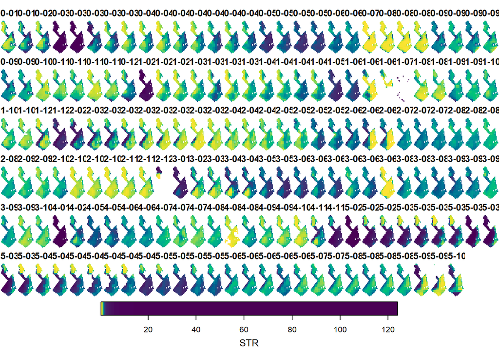

```r
# STR index
plot(
  obj_wetness[13],
  col = rev(hcl.colors(100, "viridis")),  # 2 shades of blue
  key.pos = 1,                    # put legend at the bottom (1 = below, 2 = left, 3 = above, 4 = right)
)
```

Create a summary table (without and with complete time steps) so time series of summary statistics of our AOI can be visualized.

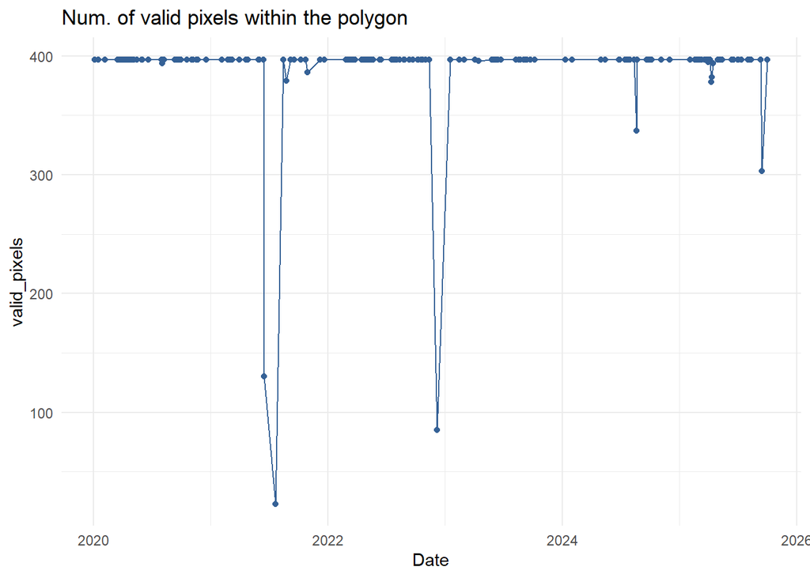

```r
# summarise
table_all <-
  obj_wetness[,,,] |>
  as_tibble() |>
  group_by(t) |>
  summarize(
    valid_pixels = sum(!is.na(NDMI)),
    NDMI_mean = mean(NDMI, na.rm = TRUE),
    NDMI_sd   = sd(NDMI, na.rm = TRUE),
    NDWI_mean = mean(NDWI, na.rm = TRUE),
    NDWI_sd = sd(NDWI, na.rm = TRUE),
    NDPI_mean = mean(NDPI, na.rm = TRUE),
    NDPI_sd = sd(NDPI, na.rm = TRUE),
    STR_mean  = mean(STR, na.rm = TRUE),
    STR_sd = sd(STR, na.rm = TRUE),
    B11_mean  = mean(B11, na.rm = TRUE),
    B11_sd  = sd(B11, na.rm = TRUE)
  )

# Fill missing dates (5-day steps)
table_all_complete <- table_all %>%
  mutate(t = as.Date(t)) %>%
  complete(t = seq.Date(min(t), max(t), by = "5 days"))

# Linear gap filling
ggplot(table_all) +
  aes(x = t, y = valid_pixels) + theme_minimal() +
  geom_line() + geom_point() +
  labs(title = "Num. of valid pixels within the polygon", x = "Date",
       y = "valid_pixels")
```

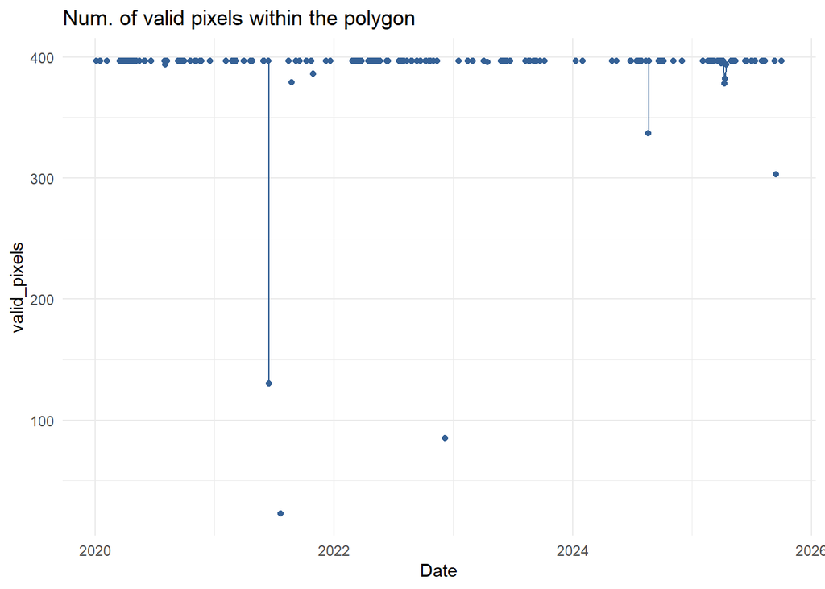

```r
# No gap filling --> irregular time series
ggplot(table_all_complete) +
  aes(x = t, y = valid_pixels) + theme_minimal() +
  geom_line() + geom_point() +
  labs(title = "Num. of valid pixels within the polygon", x = "Date",
       y = "valid_pixels")
```

Do the same for some other indices.

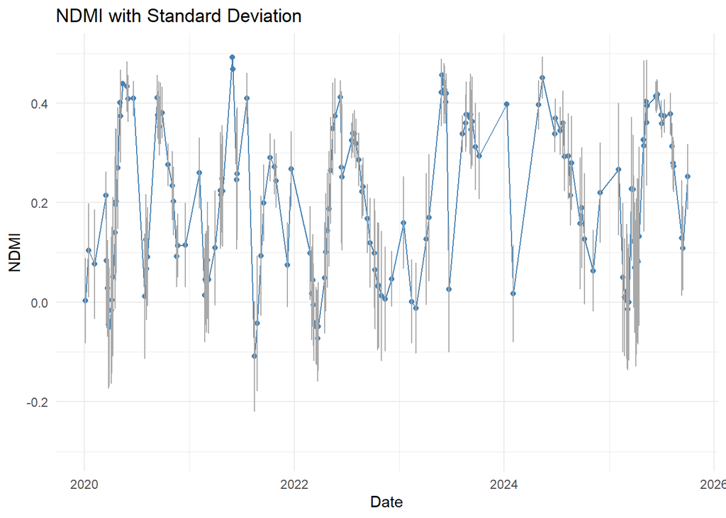

```r
ggplot(table_all, aes(x = t, y = NDMI_mean)) +
  geom_line(color = "steelblue") +
  geom_point(color = "steelblue") +
  geom_errorbar(aes(ymin = NDMI_mean - NDMI_sd,
                    ymax = NDMI_mean + NDMI_sd),
                width = 0.2, color = "darkgray") +
  theme_minimal() +
  ylim(-0.3, 0.5) +  # adjust if needed
  labs(title = "NDMI with Standard Deviation",
       x = "Date",
       y = "NDMI")
```

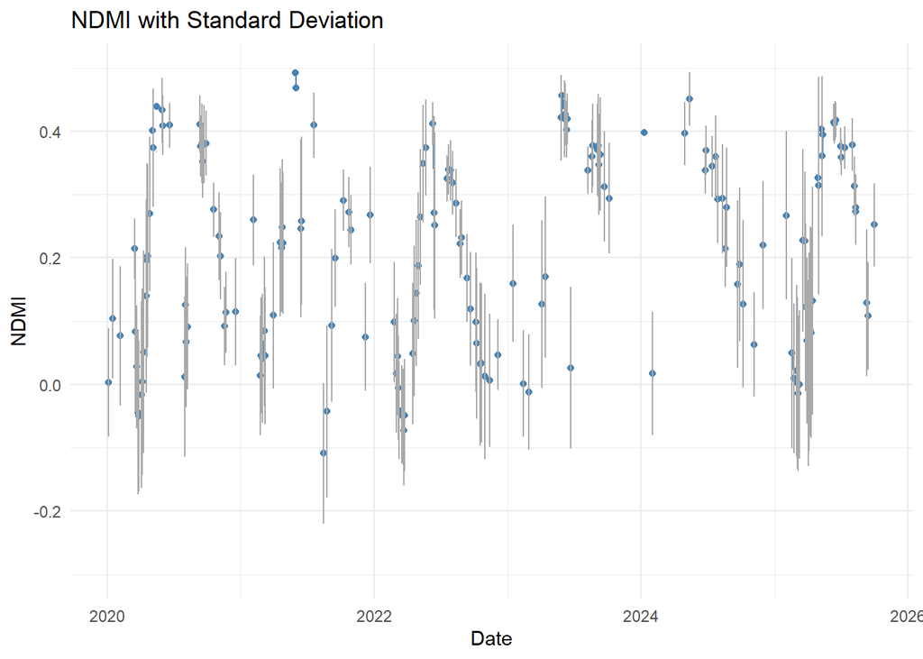

```r
ggplot(table_all_complete, aes(x = t, y = NDMI_mean)) +
  geom_line(color = "steelblue") +
  geom_point(color = "steelblue") +
  geom_errorbar(aes(ymin = NDMI_mean - NDMI_sd,
                    ymax = NDMI_mean + NDMI_sd),
                width = 0.2, color = "darkgray") +
  theme_minimal() +
  ylim(-0.3, 0.5) +  # adjust if needed
  labs(title = "NDMI with Standard Deviation",
       x = "Date",
       y = "NDMI")
```

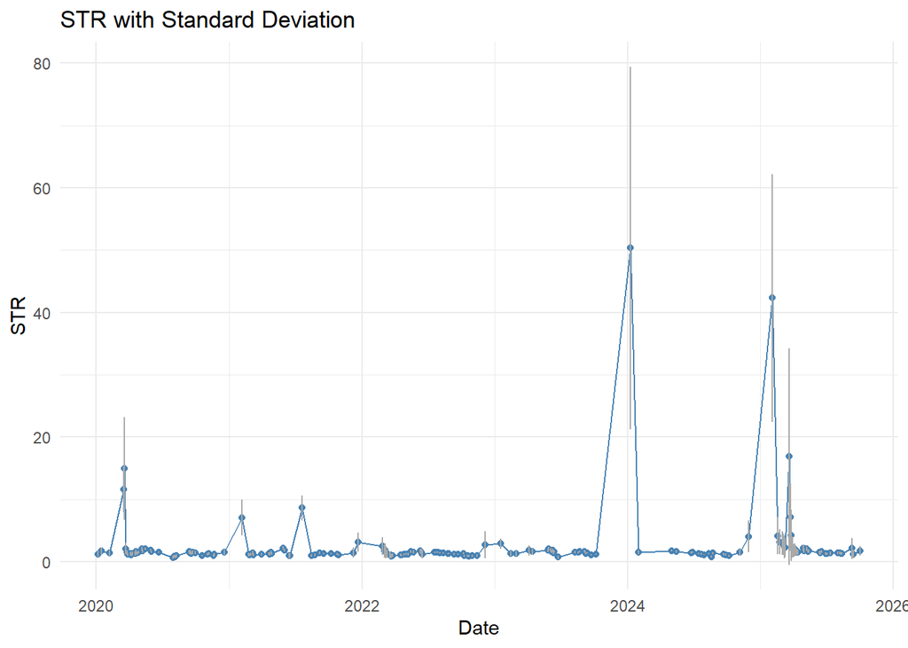

```r
ggplot(table_all, aes(x = t, y = STR_mean)) +
  geom_line(color = "steelblue") +
  geom_point(color = "steelblue") +
  geom_errorbar(aes(ymin = STR_mean - STR_sd,
                    ymax = STR_mean + STR_sd),
                width = 0.2, color = "darkgray") +
  theme_minimal() +
  labs(title = "STR with Standard Deviation",
       x = "Date",
       y = "STR")
```

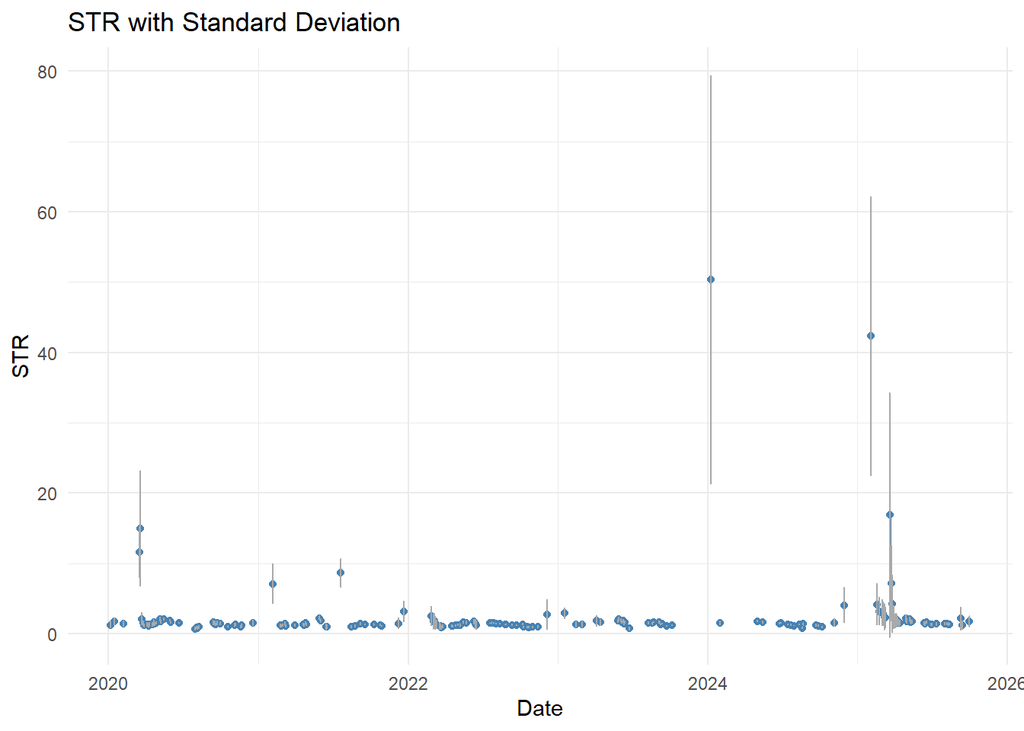

```r
ggplot(table_all_complete, aes(x = t, y = STR_mean)) +
  geom_line(color = "steelblue") +
  geom_point(color = "steelblue") +
  geom_errorbar(aes(ymin = STR_mean - STR_sd,
                    ymax = STR_mean + STR_sd),
                width = 0.2, color = "darkgray") +
  theme_minimal() +
  labs(title = "STR with Standard Deviation",
       x = "Date",
       y = "STR")
```

#### 1.1.7.1 How to deal with missing values?

**Option 1:** use a lower cloud cover filter in pre-processing and rely on cloud masking –> risky + cloud masks will still result in missing values.

**Option 2:** data fusion

e.g. Landsat - Sentinel 2 combined time-series

* https://hls.gsfc.nasa.gov/

e.g. use Sentinel-1 data to predict values for Sentinel-2

* https://blog.vito.be/remotesensing/cropsar2023

**Option 3:** data interpolation

Which interpolation should we use to fill in gaps?

*Spatial interpolation (on pixel level):*

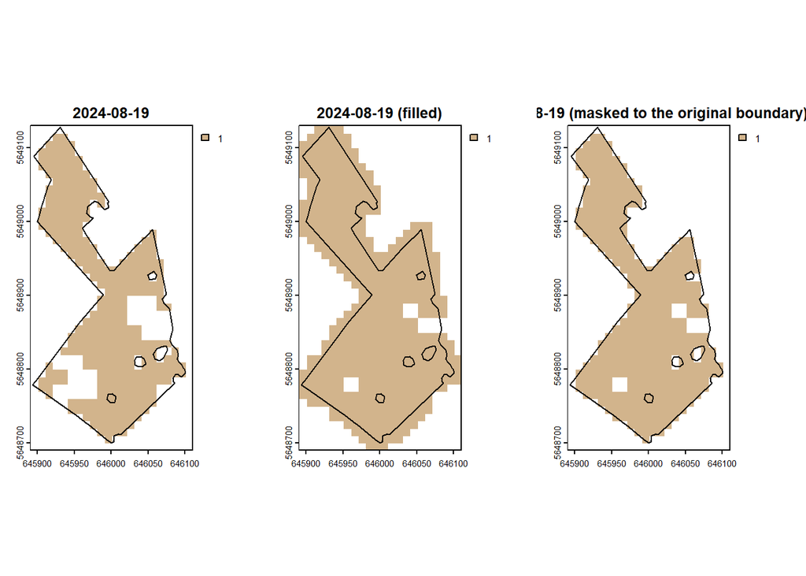

```r
par(mfrow=c(1,3))

# Extract the 67th time slice
r67_stars <- slice(obj_classified, "t", 130)

r <- rast(r67_stars)

plot(r,main="2024-08-19",col=c("tan"))
plot(st_geometry(AOI),add=T)

# Apply majority (modal) filter, but only on "NA" values.
r_focal <- focal(r, w = 3, fun = modal, na.policy = "only", na.rm = TRUE)

plot(r_focal, main = "2024-08-19 (filled)", col = c("tan"))
plot(st_geometry(AOI),add=T)

AOI_buff <- st_buffer(AOI, -6)
# Mask
r_mask <- mask(r_focal,AOI_buff)

# Plot to verify
plot(r_mask, main = "2024-08-19 (masked to the original boundary)", col = c("tan"))
plot(st_geometry(AOI),add=T)
```

```r
par(mfrow=c(1,1))
```

*Spatial interpolation (on plot level) –> won’t be shown.*

*Temporal interpolation (on plot level)*

```r
# Ensure proper date format
water_proportion_data2 <- water_proportion_data %>%
  mutate(t = as.Date(t))

# Fill missing dates (5-day steps)
water_proportion_data_complete <- water_proportion_data2 %>%
  complete(t = seq.Date(min(t), max(t), by = "5 days"))

# Store numeric x-axis for regression-based methods
water_proportion_data_complete <- water_proportion_data_complete %>%
  mutate(t_num = as.numeric(t))

# --- Interpolation Methods ---

# Linear interpolation
water_proportion_data_complete$linear <- na.approx(
  water_proportion_data_complete$proportion_water,
  x = water_proportion_data_complete$t_num, na.rm = FALSE
)

# LOESS interpolation
loess_fit <- loess(proportion_water ~ t_num,
                   data = water_proportion_data_complete,
                   span = 0.3)
water_proportion_data_complete$loess <- predict(loess_fit,
                                                newdata = water_proportion_data_complete$t_num)

# Spline interpolation
spline_fit <- splinefun(water_proportion_data_complete$t_num,
                        water_proportion_data_complete$proportion_water,
                        method = "natural")
water_proportion_data_complete$spline <- spline_fit(water_proportion_data_complete$t_num)

# Smoothing spline
smooth_fit <- smooth.spline(water_proportion_data2$t,
             water_proportion_data2$proportion_water,
             spar = 0.3)
water_proportion_data_complete$smooth_spline <- predict(smooth_fit,                                                         water_proportion_data_complete$t_num)$y

# Kernel regression (local constant / local linear)
bw <- npregbw(proportion_water ~ t_num, data = water_proportion_data_complete)
```

```
## Multistart 1 of 1 |Multistart 1 of 1 |Multistart 1 of 1 |Multistart 1 of 1 /Multistart 1 of 1 -Multistart 1 of 1 \Multistart 1 of 1 |Multistart 1 of 1 |
```

```r
kernel_fit <- npreg(bw)
water_proportion_data_complete$kernel <- predict(kernel_fit,
                                                 newdata = data.frame(t_num = water_proportion_data_complete$t_num))

# Gaussian Process regression
gp_fit <- gausspr(proportion_water~t_num,
                  data = water_proportion_data_complete,
                  kernel = "rbfdot")
```

```
## Using automatic sigma estimation (sigest) for RBF or laplace kernel
```

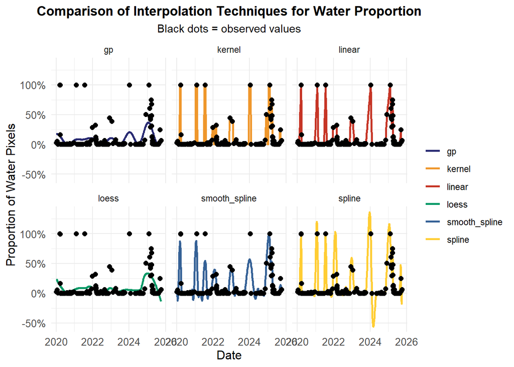

```r
water_proportion_data_complete$gp <- predict(gp_fit,
                                             newdata = data.frame(t_num = water_proportion_data_complete$t_num))


# --- Visualization: Compare Methods ---
water_long <- water_proportion_data_complete %>%
  select(t,  gp, linear,kernel,smooth_spline,loess,spline) %>%
  pivot_longer(-t, names_to = "method", values_to = "value")


ggplot(water_long, aes(x = t, y = value, color = method)) +
  geom_line(size = 1) +
  geom_point(data = water_proportion_data2,
             aes(x = t, y = proportion_water),
             color = "black", size = 2, inherit.aes = FALSE) +
  labs(
    title = "Comparison of Interpolation Techniques for Water Proportion",
    subtitle = "Black dots = observed values",
    x = "Date",
    y = "Proportion of Water Pixels"
  ) +
  scale_y_continuous(labels = scales::percent_format()) +
  theme_minimal() +
  theme(
    plot.title = element_text(hjust = 0.5, face = "bold"),
    plot.subtitle = element_text(hjust = 0.5),
    axis.title = element_text(size = 12),
    axis.text = element_text(size = 10),
    legend.title = element_blank()
  ) +
  facet_wrap(~method) # Comment this out if you want to the curves plotted on top of each other.
```

**In my opinion:** non of the methods here shown are perfect (over- and underfitting) Further tuning of the parameters is required, or additional smoothing in case of overfitting).

*Interpolation on pixel level –> fictive example*

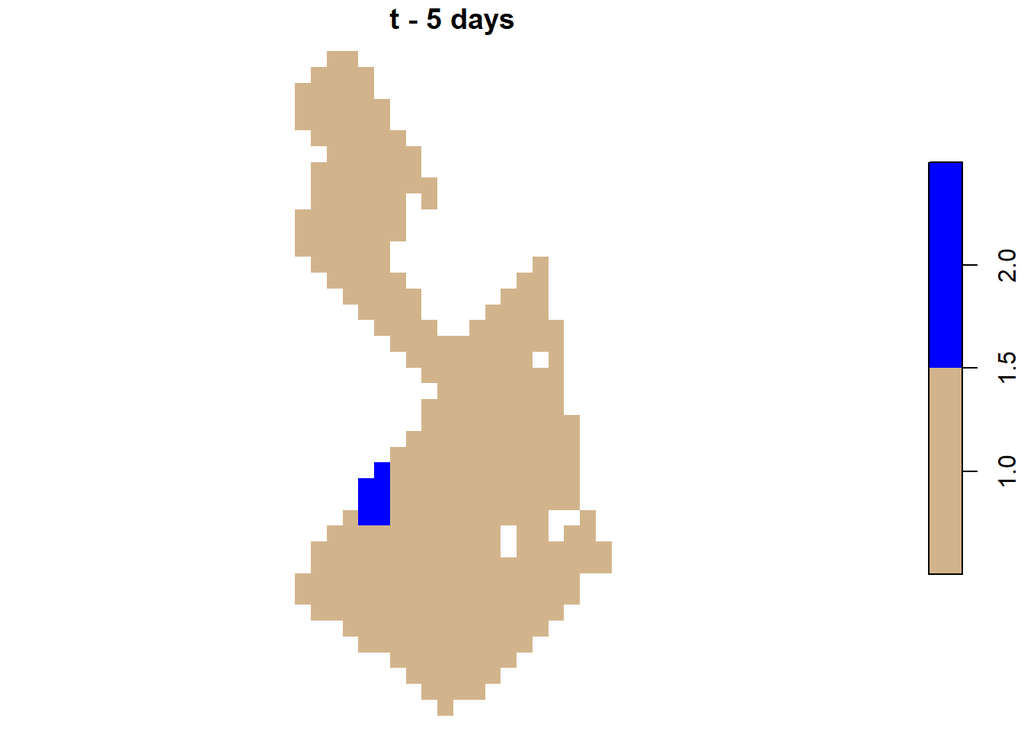

```r
slices <- obj_classified[,,,c(69,70)]

# Compute mean across the time dimension
t_mean <- st_apply(slices, MARGIN = c("x", "y"), FUN = mean, na.rm = TRUE)

# Plot result
plot(obj_classified[,,,69], main = "t - 5 days", col = c("tan","blue"))
```

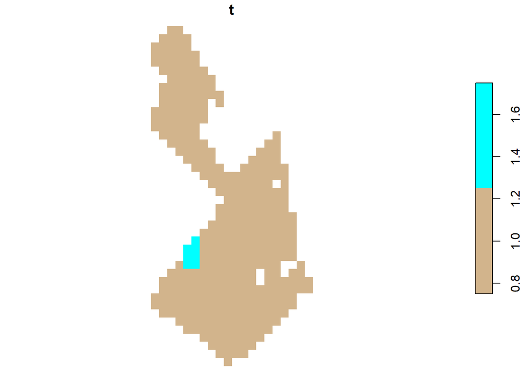

```r
plot(t_mean[1], main = "t", col = c("tan", "cyan"))
```

[figure not shown]

```r
plot(obj_classified[,,,70], main = "t + 5 days", col = c("tan"))
```

Other more advanced interpolation technique (and dataset) –> TSIRF algorithm: combines temporal interpolation, temporal smoothing and temporal aggregation.

* https://pubmed.ncbi.nlm.nih.gov/39650555/

**Option 4:** temporal data aggregation

First, we need to decide how we will temporally aggregate the classification. You can choose in the code below between monthly, seasonally (three months) or yearly. Be aware that due to clouds we won’t have an equal number of observations for each time aggregation.

The function we use is the “maximum”, indicating if a pixel was inundated within the time interval (month, season, year), it will be returned as inundated.

**Question 5: What are the advantages and disadvantages of using the min/max aggregation function? When would you use it?**

- Monthly temporal aggregation

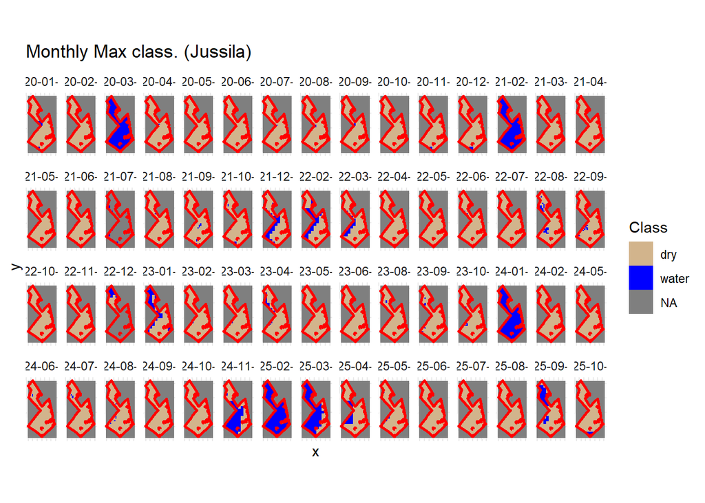

```r
# Extract classes into a tibble
classified_df <- as_tibble(obj_classified[AOI])

# Add a month column
classified_df <- classified_df %>%
  mutate(month = floor_date(t, "month"))

# Compute max and median classified value per pixel per month
classified_df_monthly_max <- classified_df %>%
  group_by(month, x, y) %>%      # group by pixel location + month
  summarize(Class = max(X, na.rm = TRUE), .groups = "drop")

classified_df_monthly_median <- classified_df %>%
  group_by(month, x, y) %>%      # group by pixel location + month
  summarize(Class = median(X, na.rm = TRUE), .groups = "drop")

# Convert -Inf values to NA
classified_df_monthly_max[classified_df_monthly_max == -Inf] <- NA
classified_df_monthly_median[classified_df_monthly_median == -Inf] <- NA

# Convert back to stars
classified_monthly_max <- st_as_stars(classified_df_monthly_max, dims = c("x", "y", "month"))

classified_monthly_median <- st_as_stars(classified_df_monthly_median, dims = c("x", "y", "month"))

# Convert the stars object to factor using st_set_dimensions
classified_monthly_max_factor <- classified_monthly_max
classified_monthly_max_factor[[1]] <- factor(
  classified_monthly_max_factor[[1]],
  levels = c(1, 2),
  labels = pred_levels
)

classified_monthly_median_factor <- classified_monthly_median
classified_monthly_median_factor[[1]] <- factor(
  classified_monthly_median_factor[[1]],
  levels = c(1, 1.5, 2),
  labels = c("dry","moist","water")
)

# Plot with discrete scale
ggplot() +
  ggtitle("Monthly Max class. (Jussila)") +
  geom_stars(data = classified_monthly_max_factor) +
  geom_sf(data = AOI, fill = NA, color = "red", linewidth = 1) +
  facet_wrap(~month,ncol=15) +
  theme_minimal() +
  theme(axis.text = element_blank(),          # remove axis tick labels
    axis.ticks = element_blank(),         # remove tick marks
    )+
  scale_fill_manual(
    name = "Class",
    values = c("dry" = "tan", "water" = "blue")
  )
```

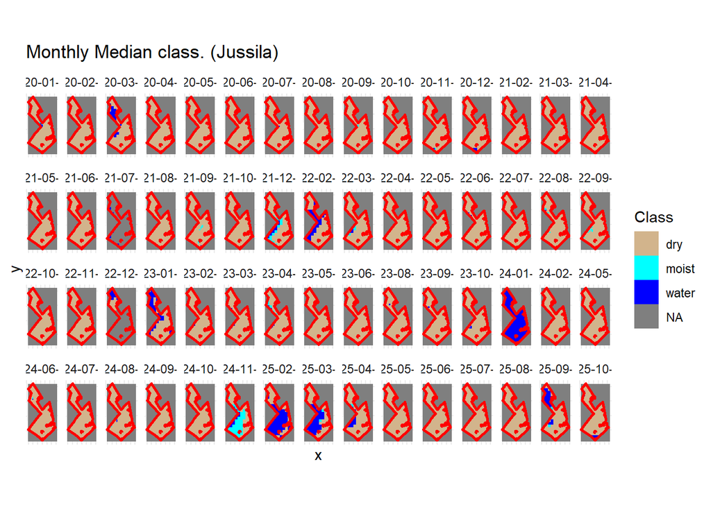

```r
ggplot() +
  ggtitle("Monthly Median class. (Jussila)") +
  geom_stars(data = classified_monthly_median_factor) +
  geom_sf(data = AOI, fill = NA, color = "red", linewidth = 1) +
  facet_wrap(~month,ncol=15) +
  theme_minimal() +
  theme(axis.text = element_blank(),          # remove axis tick labels
    axis.ticks = element_blank(),         # remove tick marks
    )+
  scale_fill_manual(
    name = "Class",
    values = c("dry" = "tan", "moist" = "cyan", "water" = "blue")
  )
```

Calculate now the % of inundation (so spatial aggregation to plot level).

For max aggregation:

```r
# For max aggregation

# Calculate the proportion of "water" pixels for each time stamp and visualize
# Convert the classified stars object to a tibble
st_crs(classified_monthly_max) <- st_crs(AOI)
classified_monthly_max_pixels <- as_tibble(classified_monthly_max[AOI])

# Rename the column for clarity and filter out NA values
names(classified_monthly_max_pixels)[which(names(classified_monthly_max_pixels) == "X")] <- "Class"

monthly_classified_max_pixels <- classified_monthly_max_pixels %>% dplyr::filter(!is.na(Class))

# Calculate total pixels and water pixels for each time step
monthly_max_water_proportion_data <- monthly_classified_max_pixels %>%
  group_by(month) %>%
  summarize(
    total_pixels = n(),
    water_pixels = sum(Class == 2, na.rm = TRUE), # Class 2 is 'water'
    .groups = "drop"
  ) %>%
  mutate(
    proportion_water = water_pixels / total_pixels
  )

# Print the resulting tibble with proportions
print(monthly_max_water_proportion_data)
```

```
## # A tibble: 60 × 4
##    month               total_pixels water_pixels proportion_water
##    <dttm>                     <int>        <int>            <dbl>
##  1 2020-01-01 00:00:00          397           22          0.0554
##  2 2020-02-01 00:00:00          397            1          0.00252
##  3 2020-03-01 00:00:00          397          397          1
##  4 2020-04-01 00:00:00          397            2          0.00504
##  5 2020-05-01 00:00:00          397            0          0
##  6 2020-06-01 00:00:00          397            0          0
##  7 2020-07-01 00:00:00          397            2          0.00504
##  8 2020-08-01 00:00:00          397            5          0.0126
##  9 2020-09-01 00:00:00          397            7          0.0176
## 10 2020-10-01 00:00:00          397            0          0
## # ℹ 50 more rows
```

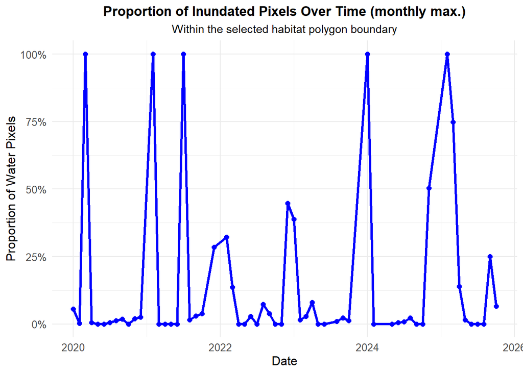

```r
# Visualize the time series of water proportion
ggplot(monthly_max_water_proportion_data, aes(x = month, y = proportion_water)) +
  geom_line(color = "blue", size = 1.2) +
  geom_point(color = "blue", size = 2) +
  labs(
    title = "Proportion of Inundated Pixels Over Time (monthly max.)",
    subtitle = "Within the selected habitat polygon boundary",
    x = "Date",
    y = "Proportion of Water Pixels"
  ) +
  theme_minimal() +
  scale_y_continuous(labels = scales::percent_format()) +
  theme(
    plot.title = element_text(hjust = 0.5, face = "bold"),
    plot.subtitle = element_text(hjust = 0.5),
    axis.title = element_text(size = 12),
    axis.text = element_text(size = 10)
  )
```

For median aggregation:

```r
# For median aggregation --> consider the pixels values as "discrete".

# Calculate the proportion of "water" and "moist" pixels for each time stamp and visualize
# Convert the classified stars object to a tibble
st_crs(classified_monthly_median) <- st_crs(AOI)
classified_monthly_median_pixels <- as_tibble(classified_monthly_median[AOI])

# Rename the column for clarity and filter out NA values
names(classified_monthly_median_pixels)[which(names(classified_monthly_median_pixels) == "X")] <- "Class"

monthly_classified_median_pixels <- classified_monthly_median_pixels %>% dplyr::filter(!is.na(Class))

# Calculate total pixels and water pixels for each time step
monthly_median_water_proportion_data <- monthly_classified_median_pixels %>%
  group_by(month) %>%
  summarize(
    total_pixels = n(),
    water_pixels = sum(Class == 2, na.rm = TRUE), # Class 2 is 'water'
    moist_pixels = sum(Class == 1.5, na.rm =TRUE), #Class 1.5 is 'moist'
    .groups = "drop"
  ) %>%
  mutate(
    proportion_water = water_pixels / total_pixels,
    proportion_moist = moist_pixels / total_pixels,
  )

# Print the resulting tibble with proportions
print(monthly_median_water_proportion_data)
```

```
## # A tibble: 60 × 6
##    month               total_pixels water_pixels moist_pixels proportion_water
##    <dttm>                     <int>        <int>        <int>            <dbl>
##  1 2020-01-01 00:00:00          397           10           12          0.0252
##  2 2020-02-01 00:00:00          397            1            0          0.00252
##  3 2020-03-01 00:00:00          397           65            0          0.164
##  4 2020-04-01 00:00:00          397            0            0          0
##  5 2020-05-01 00:00:00          397            0            0          0
##  6 2020-06-01 00:00:00          397            0            0          0
##  7 2020-07-01 00:00:00          397            2            0          0.00504
##  8 2020-08-01 00:00:00          397            1            0          0.00252
##  9 2020-09-01 00:00:00          397            0            3          0
## 10 2020-10-01 00:00:00          397            0            0          0
## # ℹ 50 more rows
## # ℹ 1 more variable: proportion_moist <dbl>
```

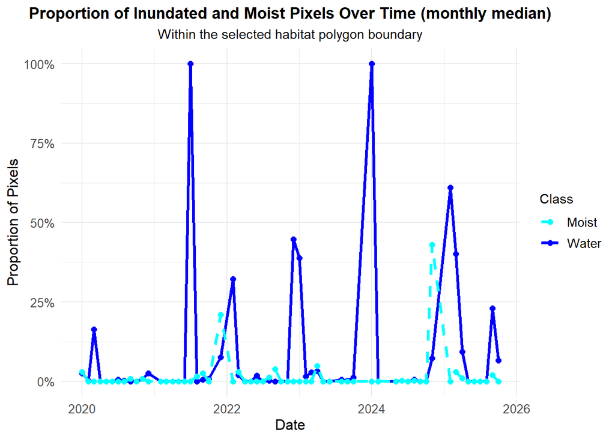

```r
# Visualize both water and moist proportions over time
ggplot(monthly_median_water_proportion_data, aes(x = month)) +
  geom_line(aes(y = proportion_water, color = "Water"), size = 1.2) +
  geom_point(aes(y = proportion_water, color = "Water"), size = 2) +
  geom_line(aes(y = proportion_moist, color = "Moist"), size = 1.2, linetype = "dashed") +
  geom_point(aes(y = proportion_moist, color = "Moist"), size = 2) +
  labs(
    title = "Proportion of Inundated and Moist Pixels Over Time (monthly median)",
    subtitle = "Within the selected habitat polygon boundary",
    x = "Date",
    y = "Proportion of Pixels",
    color = "Class"
  ) +
  theme_minimal() +
  scale_y_continuous(labels = scales::percent_format()) +
  scale_color_manual(values = c("Water" = "blue", "Moist" = "cyan")) +
  theme(
    plot.title = element_text(hjust = 0.5, face = "bold"),
    plot.subtitle = element_text(hjust = 0.5),
    axis.title = element_text(size = 12),
    axis.text = element_text(size = 10),
    legend.title = element_text(size = 11),
    legend.text = element_text(size = 10)
  )
```

Reshape data for stacked plotting

```r
# Reshape data for stacked plotting
monthly_median_long <- monthly_median_water_proportion_data %>%
  select(month, proportion_water, proportion_moist) %>%
  tidyr::pivot_longer(
    cols = starts_with("proportion_"),
    names_to = "Class",
    values_to = "Proportion"
  ) %>%
  mutate(
    Class = recode(Class,
                   proportion_water = "Water",
                   proportion_moist = "Moist")
  )

# Print the resulting tibble with proportions
print(monthly_median_long)
```

```
## # A tibble: 120 × 3
##    month               Class Proportion
##    <dttm>              <chr>      <dbl>
##  1 2020-01-01 00:00:00 Water    0.0252
##  2 2020-01-01 00:00:00 Moist    0.0302
##  3 2020-02-01 00:00:00 Water    0.00252
##  4 2020-02-01 00:00:00 Moist    0
##  5 2020-03-01 00:00:00 Water    0.164
##  6 2020-03-01 00:00:00 Moist    0
##  7 2020-04-01 00:00:00 Water    0
##  8 2020-04-01 00:00:00 Moist    0
##  9 2020-05-01 00:00:00 Water    0
## 10 2020-05-01 00:00:00 Moist    0
## # ℹ 110 more rows
```

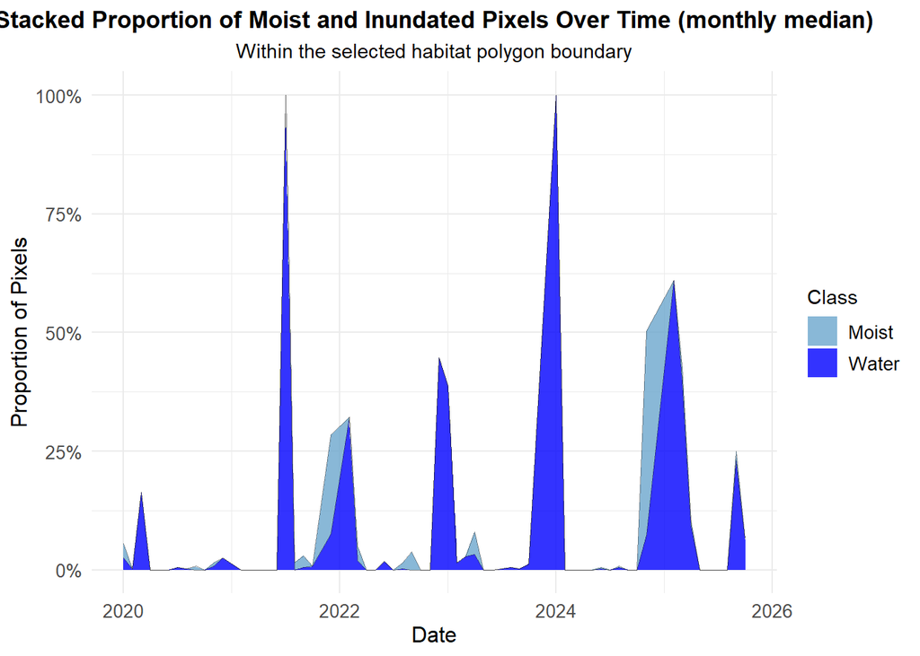

```r
# Create stacked area chart
ggplot(monthly_median_long, aes(x = month, y = Proportion, fill = Class)) +
  geom_area(position = "stack", alpha = 0.8) +
  geom_line(position = "stack", color = "black", size = 0.2, alpha = 0.4) +
  labs(
    title = "Stacked Proportion of Moist and Inundated Pixels Over Time (monthly median)",
    subtitle = "Within the selected habitat polygon boundary",
    x = "Date",
    y = "Proportion of Pixels",
    fill = "Class"
  ) +
  scale_y_continuous(labels = scales::percent_format()) +
  scale_fill_manual(values = c("Water" = "blue", "Moist" = "skyblue3")) +
  theme_minimal() +
  theme(
    plot.title = element_text(hjust = 0.5, face = "bold"),
    plot.subtitle = element_text(hjust = 0.5),
    axis.title = element_text(size = 12),
    axis.text = element_text(size = 10),
    legend.title = element_text(size = 11),
    legend.text = element_text(size = 10)
  )
```

For median aggregation, when pixels are considered as “continuous” instead of “catagorical”.

```r
# For median aggregation --> consider the pixels as "continuous".

# Calculate the average pixel value for each time step
monthly_median_water_proportion_data2 <- monthly_classified_median_pixels %>%
  group_by(month) %>%
  mutate(
    proportion_water = mean(Class, na.rm = TRUE),
  )

# Print the resulting tibble with proportions
print(monthly_median_water_proportion_data2)
```

```
## # A tibble: 23,134 × 5
## # Groups:   month [60]
##         x       y month               Class proportion_water
##     <dbl>   <dbl> <dttm>              <dbl>            <dbl>
##  1 645925 5649115 2020-01-01 00:00:00     1             1.04
##  2 645935 5649115 2020-01-01 00:00:00     1             1.04
##  3 645915 5649105 2020-01-01 00:00:00     1             1.04
##  4 645925 5649105 2020-01-01 00:00:00     1             1.04
##  5 645935 5649105 2020-01-01 00:00:00     1             1.04
##  6 645945 5649105 2020-01-01 00:00:00     1             1.04
##  7 645905 5649095 2020-01-01 00:00:00     1             1.04
##  8 645915 5649095 2020-01-01 00:00:00     1             1.04
##  9 645925 5649095 2020-01-01 00:00:00     1             1.04
## 10 645935 5649095 2020-01-01 00:00:00     1             1.04
## # ℹ 23,124 more rows
```

```
## Ignoring unknown labels:
## • colour : "Class"
```

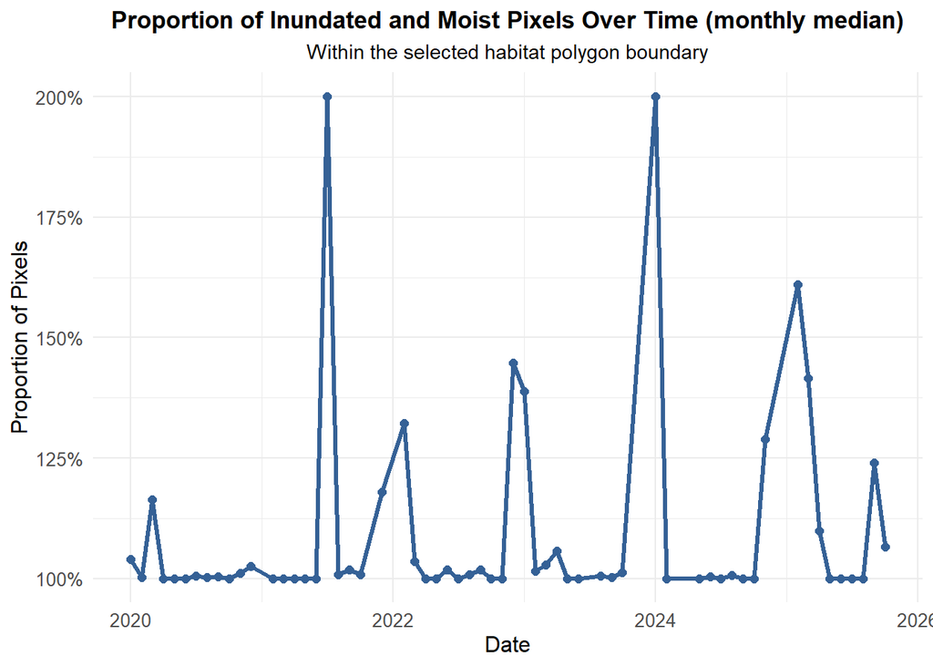

```r
# Visualize both water and moist proportions over time
ggplot(monthly_median_water_proportion_data2, aes(x = month,y = proportion_water)) +
  geom_line(,size = 1.2) +
  geom_point(size = 2) +
    labs(
    title = "Proportion of Inundated and Moist Pixels Over Time (monthly median)",
    subtitle = "Within the selected habitat polygon boundary",
    x = "Date",
    y = "Proportion of Pixels",
    color = "Class"
  ) +
  theme_minimal() +
  scale_y_continuous(labels = scales::percent_format()) +
  theme(
    plot.title = element_text(hjust = 0.5, face = "bold"),
    plot.subtitle = element_text(hjust = 0.5),
    axis.title = element_text(size = 12),
    axis.text = element_text(size = 10),
    legend.title = element_text(size = 11),
    legend.text = element_text(size = 10)
  )
```

Again - compare with the missing data:

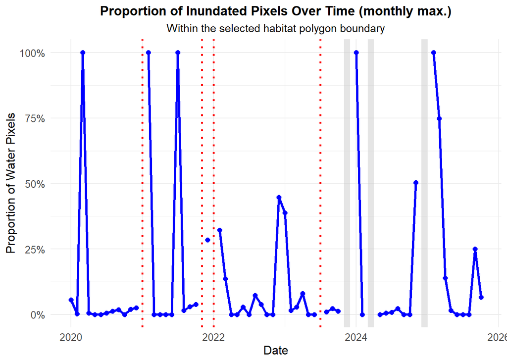

```r
# Adapt the plot, to see the monthly gaps within the time-series
# Create a complete sequence of months covering the full range
all_months <- tibble(month = seq(min(monthly_max_water_proportion_data$month),
                                 max(monthly_max_water_proportion_data$month),
                                 by = "1 month"))

# Fill missing months with NA
plot_data <- all_months %>%
  left_join(monthly_max_water_proportion_data, by = "month")

# --- Identify missing stretches ---
missing_info <- plot_data %>%
  mutate(is_missing = is.na(proportion_water),
         gap_id = cumsum(!is_missing)) %>%
  dplyr::filter(is_missing) %>%
  group_by(gap_id) %>%
  summarise(start = min(month), end = max(month), .groups = "drop")

# Split into multi-month gaps vs single missing months
missing_multi <- missing_info %>%
  dplyr::filter(start != end) %>%
  mutate(end = end + 30)   # extend end by ~1 month for shading

missing_single <- missing_info %>%
  dplyr::filter(start == end)

# --- Plot ---
ggplot(plot_data, aes(x = month, y = proportion_water)) +
  # Shaded missing ranges
  geom_rect(data = missing_multi,
            aes(xmin = start, xmax = end, ymin = -Inf, ymax = Inf),
            inherit.aes = FALSE,
            fill = "grey80", alpha = 0.5) + # gray zones for multiple missing months
  # Red dotted lines for isolated missing months
  geom_vline(data = missing_single,
             aes(xintercept = as.numeric(start)),
             color = "red", linetype = "dotted", size = 1) + # red lines for one missing month
  # Actual time series
  geom_line(color = "blue", size = 1.2, na.rm = FALSE) +
  geom_point(color = "blue", size = 2, na.rm = TRUE) +
  labs(
    title = "Proportion of Inundated Pixels Over Time (monthly max.)",
    subtitle = "Within the selected habitat polygon boundary",
    x = "Date",
    y = "Proportion of Water Pixels"
  ) +
  theme_minimal() +
  scale_y_continuous(labels = percent_format()) +
  theme(
    plot.title = element_text(hjust = 0.5, face = "bold"),
    plot.subtitle = element_text(hjust = 0.5),
    axis.title = element_text(size = 12),
    axis.text = element_text(size = 10)
  )
```

(ignore) Add a seasonal trend. Be aware that the time series is rather short to do a read ‘trend’ analysis and that the trend is prone to missing data and “false predictions” by the model. *–> we won’t do this in the workshop.*

- Seasonal (3 months) temporal aggregation (optional)

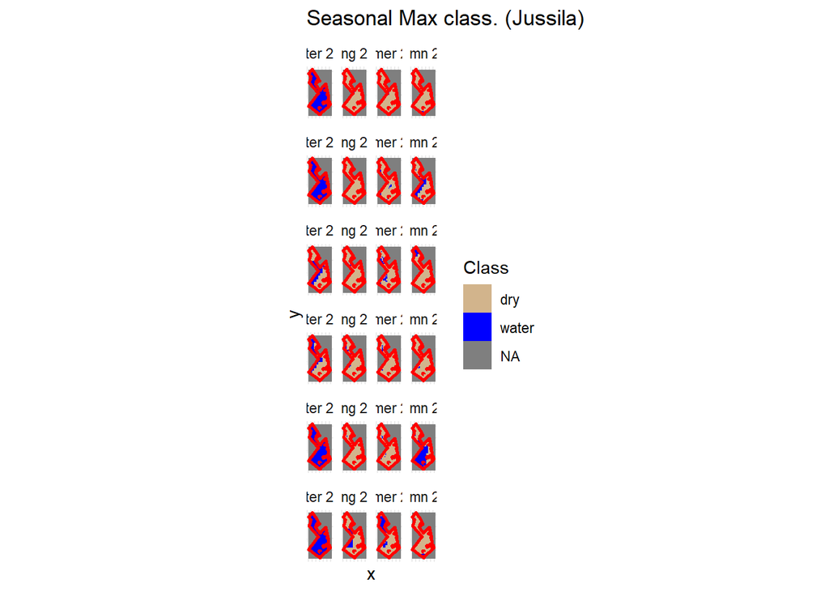

```r
classified_df <- as_tibble(obj_classified[AOI])

# Add a season column (Winter, Spring, Summer, Autumn + year)
classified_df <- classified_df %>%
  mutate(
    season_start = floor_date(t, "quarter"),
    year = year(season_start),
    quarter = quarter(season_start),
    season = case_when(
      quarter == 1 ~ "Winter",
      quarter == 2 ~ "Spring",
      quarter == 3 ~ "Summer",
      quarter == 4 ~ "Autumn"
    ),
    # ordered factor for correct sorting
    season = factor(season, levels = c("Winter", "Spring", "Summer", "Autumn"), ordered = TRUE),
    season_label = paste0(season, " ", year)
  )

# Ensure season_label is ordered correctly (by year + season order)
classified_df <- classified_df %>%
  arrange(year, season) %>%
  mutate(season_label = factor(season_label, levels = unique(season_label)))

# Compute max classified value per pixel per season
classified_df_seasonal <- classified_df %>%
  group_by(season_label, x, y) %>%
  summarize(Class = max(X, na.rm = TRUE), .groups = "drop")

# Convert -Inf values to NA
classified_df_seasonal[classified_df_seasonal == -Inf] <- NA

# Convert back to stars
classified_seasonal <- st_as_stars(classified_df_seasonal, dims = c("x", "y", "season_label"))

# Convert to factor
classified_seasonal_factor <- classified_seasonal
classified_seasonal_factor[[1]] <- factor(
  classified_seasonal_factor[[1]],
  levels = c(1, 2),
  labels = pred_levels
)

# Plot with discrete scale and season labels
ggplot() +
  ggtitle("Seasonal Max class. (Jussila)") +
  geom_stars(data = classified_seasonal_factor) +
  geom_sf(data = AOI, fill = NA, color = "red", linewidth = 1) +
  facet_wrap(~season_label, ncol=4) +
  theme_minimal() +
  theme(axis.text = element_blank(),          # remove axis tick labels
    axis.ticks = element_blank(),         # remove tick marks
    ) +
  scale_fill_manual(
    name = "Class",
    values = c("dry" = "tan", "water" = "blue")
  )
```

```r
# Calculate proportion of "water" pixels for each season
st_crs(classified_seasonal) <- st_crs(AOI)
classified_seasonal_pixels <- as_tibble(classified_seasonal[AOI])

names(classified_seasonal_pixels)[which(names(classified_seasonal_pixels) == "X")] <- "Class"
seasonal_classified_pixels <- classified_seasonal_pixels %>% dplyr::filter(!is.na(Class))

seasonal_water_proportion_data <- seasonal_classified_pixels %>%
  group_by(season_label) %>%
  summarize(
    total_pixels = n(),
    water_pixels = sum(Class == 2, na.rm = TRUE),
    .groups = "drop"
  ) %>%
  mutate(
    proportion_water = water_pixels / total_pixels
  )

print(seasonal_water_proportion_data)
```

```
## # A tibble: 24 × 4
##    season_label total_pixels water_pixels proportion_water
##    <fct>               <int>        <int>            <dbl>
##  1 Winter 2020           397          397          1
##  2 Spring 2020           397            2          0.00504
##  3 Summer 2020           397           12          0.0302
##  4 Autumn 2020           397           11          0.0277
##  5 Winter 2021           397          397          1
##  6 Spring 2021           397            0          0
##  7 Summer 2021           397           37          0.0932
##  8 Autumn 2021           397          120          0.302
##  9 Winter 2022           397          128          0.322
## 10 Spring 2022           397           11          0.0277
## # ℹ 14 more rows
```

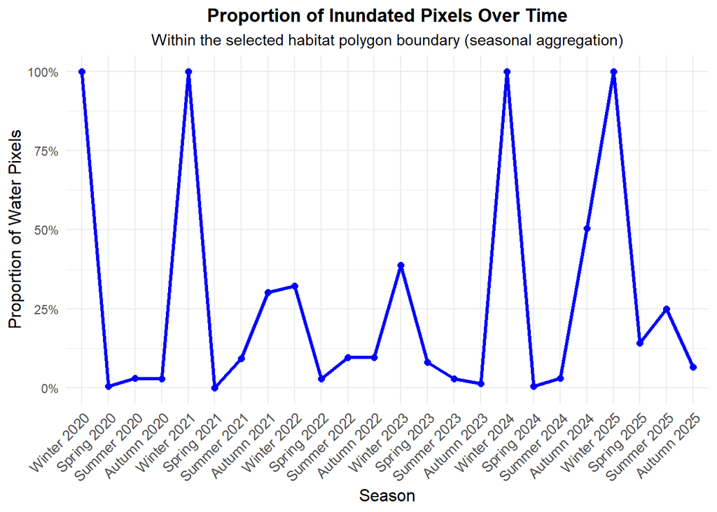

```r
# Plot time series with labeled seasons
ggplot(seasonal_water_proportion_data, aes(x = season_label, y = proportion_water, group = 1)) +
  geom_line(color = "blue", size = 1.2) +
  geom_point(color = "blue", size = 2) +
  labs(
    title = "Proportion of Inundated Pixels Over Time",
    subtitle = "Within the selected habitat polygon boundary (seasonal aggregation)",
    x = "Season",
    y = "Proportion of Water Pixels"
  ) +
  theme_minimal() +
  scale_y_continuous(labels = scales::percent_format()) +
  theme(
    plot.title = element_text(hjust = 0.5, face = "bold"),
    plot.subtitle = element_text(hjust = 0.5),
    axis.title = element_text(size = 12),
    axis.text.x = element_text(size = 10, angle = 45, hjust = 1)
  )
```

- Yearly temporal aggregation (optional)

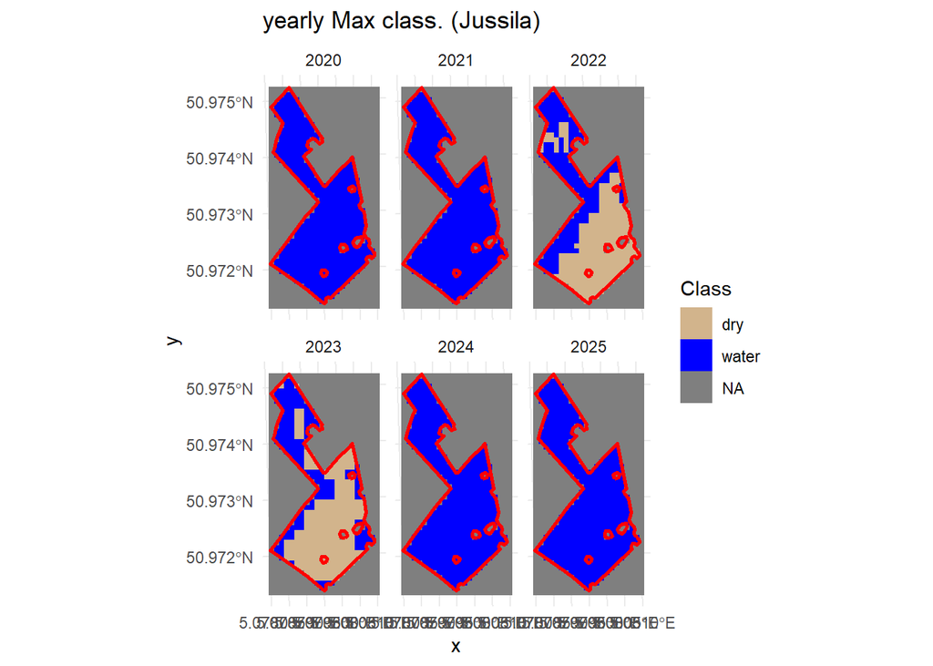

```r
# Add a month column
classified_df_y <- classified_df %>%
  mutate(month = floor_date(t, "year"))

# Compute max classified value per pixel per month
classified_df_yearly <- classified_df_y %>%
  group_by(year, x, y) %>%      # group by pixel location + month
  summarize(Class = max(X, na.rm = TRUE), .groups = "drop")

# Convert -Inf values to NA
classified_df_yearly[classified_df_yearly == -Inf] <- NA

# Convert back to stars
classified_yearly <- st_as_stars(classified_df_yearly, dims = c("x", "y", "year"))

# Convert the stars object to factor using st_set_dimensions
classified_yearly_factor <- classified_yearly
classified_yearly_factor[[1]] <- factor(
  classified_yearly_factor[[1]],
  levels = c(1, 2),
  labels = pred_levels
)

# Plot with discrete scale
ggplot() +
  ggtitle("yearly Max class. (Jussila)") +
  geom_stars(data = classified_yearly_factor) +
  geom_sf(data = AOI, fill = NA, color = "red", linewidth = 1) +
  facet_wrap(~year) +
  theme_minimal() +
  scale_fill_manual(
    name = "Class",
    values = c("dry" = "tan", "water" = "blue")
  )
```

```r
# Calculate the proportion of "water" pixels for each time stamp and visualize
# Convert the classified stars object to a tibble
st_crs(classified_yearly) <- st_crs(AOI)
classified_yearly_pixels <- as_tibble(classified_yearly[AOI])

# Rename the column for clarity and filter out NA values
names(classified_yearly_pixels)[which(names(classified_yearly_pixels) == "X")] <- "Class"
yearly_classified_pixels <- classified_yearly_pixels %>% dplyr::filter(!is.na(Class))

# Calculate total pixels and water pixels for each time step
yearly_water_proportion_data <- yearly_classified_pixels %>%
  group_by(year) %>%
  summarize(
    total_pixels = n(),
    water_pixels = sum(Class == 2, na.rm = TRUE), # Class 2 is 'water'
    .groups = "drop"
  ) %>%
  mutate(
    proportion_water = water_pixels / total_pixels
  )

# Print the resulting tibble with proportions
print(yearly_water_proportion_data)
```

```
## # A tibble: 6 × 4
##    year total_pixels water_pixels proportion_water
##   <dbl>        <int>        <int>            <dbl>
## 1  2020          397          397            1
## 2  2021          397          397            1
## 3  2022          397          172            0.433
## 4  2023          397          154            0.388
## 5  2024          397          397            1
## 6  2025          397          397            1
```

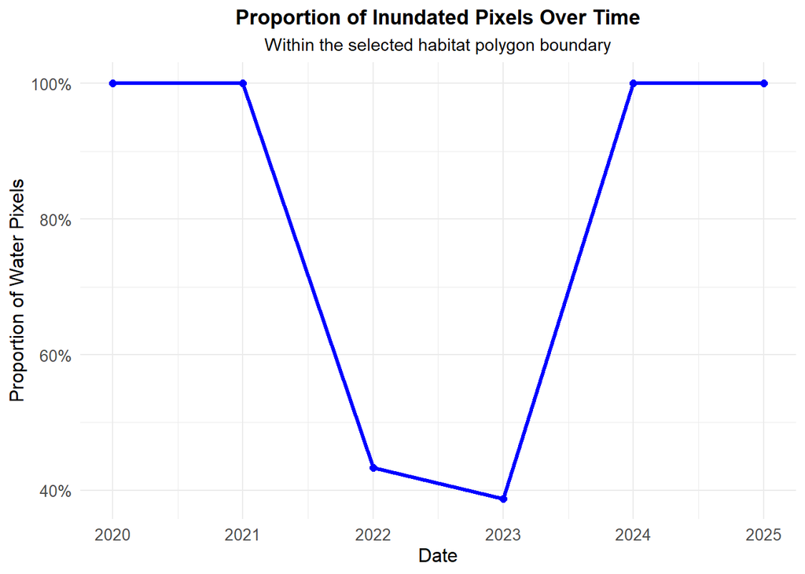

```r
# Visualize the time series of water proportion
ggplot(yearly_water_proportion_data, aes(x = year, y = proportion_water)) +
  geom_line(color = "blue", size = 1.2) +
  geom_point(color = "blue", size = 2) +
  labs(
    title = "Proportion of Inundated Pixels Over Time",
    subtitle = "Within the selected habitat polygon boundary",
    x = "Date",
    y = "Proportion of Water Pixels"
  ) +
  theme_minimal() +
  scale_y_continuous(labels = scales::percent_format()) +
  theme(
    plot.title = element_text(hjust = 0.5, face = "bold"),
    plot.subtitle = element_text(hjust = 0.5),
    axis.title = element_text(size = 12),
    axis.text = element_text(size = 10)
  )
```